# FirstMarkdown

JournKim

2017년 11월 19일

# 데이터 분석 보고서 만들기

## R 마크다운이란?

마크다운 문법으로 코드를 작성해 [HTML](http://naver.com)로 변환할 수 있습니다. R 마크다운을 이용하면 분석 과정과 결과를 자세하게 기술할 수 있기 때문에 **재현 가능성**을 갖춘 *데이터 분석 보고서*를 만들 수 있습니다.

물결표시 두 개를 이용해 취소선을 만든다.

### R 마크다운 문법 예제

아래와 같이 작성하면 코드와 함께 ’summary(cars)’를 실행한 결과물이 출력됩니다.

### R 마크다운 문법 예제

아래와 같이 작성하면 코드와 함께 ’summary(cars)’를 실행한 결과물이 출력됩니다.

```r
summary(cars)
```

```
##      speed           dist
##  Min.   : 4.0   Min.   :  2.00
##  1st Qu.:12.0   1st Qu.: 26.00
##  Median :15.0   Median : 36.00
##  Mean   :15.4   Mean   : 42.98
##  3rd Qu.:19.0   3rd Qu.: 56.00
##  Max.   :25.0   Max.   :120.00
```

- 별도로 이미지 파일을 붙여 넣는 작업을 하지 않아도 코드 아래에 그래프를 삽입할 수 있습니다.
  - 줄 앞에 별 표시(*)를 붙이는 것으로 sublist를 만들 수 있다.
    - 띄어쓰기 4개로 다음 단계의 sublist를 만들 수 있다.
      - asdf
        - ttt

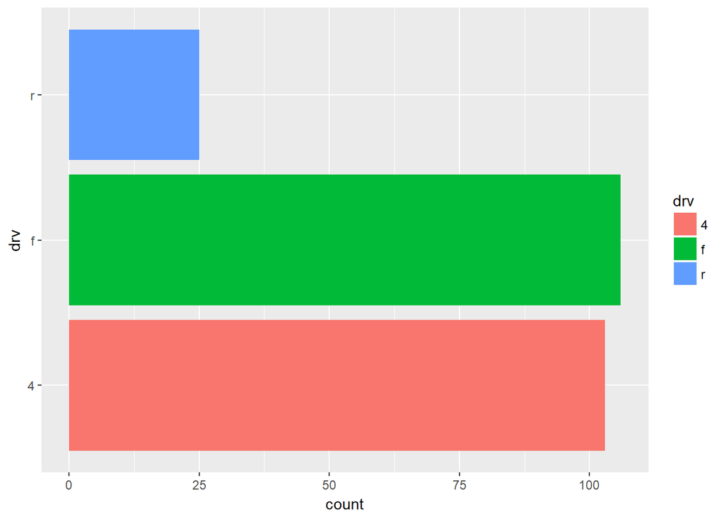

```r
library(ggplot2)
qplot(data = mpg, x = drv, fill = drv)+
  coord_flip()
```

backtick 기호 (`)를 코드 앞뒤에 넣으면 음영처리 된다. 데이터 앞부분 일부를 출력하려면 `head()`를 이용하면 된다. `tail()`은 데이터 뒷부분 일부를 출력한다.

Ctrl+Alt+I를 누르면 코드청크가 삽입된다.

```r
"Hello World"
```

```
## [1] "Hello World"
```